# Kinnaird-Test_a_Perceptual_Phenomenon

### Analyzing the Stroop Effect

Perform the analysis in the space below. Remember to follow [the instructions](https://docs.google.com/document/d/1-OkpZLjG_kX9J6LIQ5IltsqMzVWjh36QpnP2RYpVdPU/pub?embedded=True) and review the [project rubric](https://review.udacity.com/#!/rubrics/71/view) before submitting. Once you've completed the analysis and write up, download this file as a PDF or HTML file and submit in the final section of this lesson.

(1) What is the independent variable? What is the dependent variable?

##### Independent Variable: The congruent or incongruent stimulus. The congruent stimulus is when the color of the ink matches the color named. The incongruent stimulus is when the color of the ink does not match the color named.

##### Dependent Variable: The speed in seconds of the partipant's response to the congruent or incongruent stimulus.

(2) What is an appropriate set of hypotheses for this task? Specify your null and alternative hypotheses, and clearly define any notation used. Justify your choices.

##### The null hypotheses: the population mean of the differences of speed in seconds of the participant's response to the congruent stimulus (μ<sub>c</sub>) equals the population mean of the differences of speed in seconds of the participant's response to the incongruent stimulus (μ<sub>i</sub>).

##### The alternative hypothesis: the population mean of the differences of speed in seconds of the participant's response to the congruent stimulus (μ<sub>c</sub>) does not equal the population mean of the differences of speed in seconds of the participant's response to the incongruent stimulus (μ<sub>i</sub>).

##### μ<sub>c</sub> = the population mean of the speed in seconds of the participant's response to the congruent stimulus

##### μ<sub>i</sub> = the population mean of the speed in seconds of the participant's response to the incongruent stimulus

##### **$H_{0}$** = null hypothesis

##### **$H_{1}$** = alternative hypothesis

##### **$H_{0}$**: μ<sub>c</sub> = μ<sub>i</sub>

##### **$H_{1}$**: μ<sub>c</sub> ≠ μ<sub>i</sub>

##### These hypotheses are based on [conclusions previously found by John Ridley Stroop and others.](https://en.wikipedia.org/wiki/Stroop_effect)

##### To test this hypotheses, a paired t-test with a confidence interval of 5% will be performed. A paired t-test is chosen because of the size of the sample (24 participants) and type of experiment "[observations in one sample can be paired with observations in the other sample](http://www.statstutor.ac.uk/resources/uploaded/paired-t-test.pdf)" becuase each test, congruent and incongruent stimulus, is performed on each participant).

(3) Report some descriptive statistics regarding this dataset. Include at least one measure of central tendency and at least one measure of variability. The name of the data file is 'stroopdata.csv'.

```python
# Import libraries and dataset
import pandas as pd
import numpy as np
import random
import matplotlib.pyplot as plt
import scipy.stats as stats
%matplotlib inline

df = pd.read_csv('stroopdata.csv')

# Preview dataset
df.head()
```

|  | Congruent | Incongruent |
| --- | --- | --- |
| 0 | 12.079 | 19.278 |
| 1 | 16.791 | 18.741 |
| 2 | 9.564 | 21.214 |
| 3 | 8.630 | 15.687 |
| 4 | 14.669 | 22.803 |

```python
# Calculate mean, standard deviation, median, range, interquartile range
df.describe()
```

|  | Congruent | Incongruent |
| --- | --- | --- |
| count | 24.000000 | 24.000000 |
| mean | 14.051125 | 22.015917 |
| std | 3.559358 | 4.797057 |
| min | 8.630000 | 15.687000 |
| 25% | 11.895250 | 18.716750 |
| 50% | 14.356500 | 21.017500 |
| 75% | 16.200750 | 24.051500 |
| max | 22.328000 | 35.255000 |

##### The mean speed in seconds of the partipant's response to the congruent stimlulus is 14.0511 seconds. The mean for the incongruent stimulus is 22.0159 seconds.

##### The standard deviation of speed in seconds of the partipant's response to the congruent stimlulus is 3.5594 seconds. The mean for the incongruent stimulus is 4.7971 seconds.

(4) Provide one or two visualizations that show the distribution of the sample data. Write one or two sentences noting what you observe about the plot or plots.

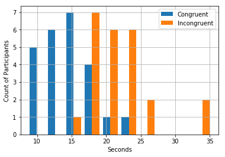

```python
# Histogram of sample data
plt.hist([df['Congruent'], df['Incongruent']],histtype='bar')
plt.xlabel('Seconds')
plt.ylabel('Count of Participants')
plt.legend(df)
plt.grid(True)
plt.show()
```

##### The plot above shows the distribution of speed in seconds of the partipant's response to a congruent or incongruent stimulus. This plot shows the response to a congruent stimulus tends toward a shorter amount of time and a response to an incongruent stimulus tends toward a longer amount of time.

(5) Now, perform the statistical test and report your results. What is your confidence level or Type I error associated with your test? What is your conclusion regarding the hypotheses you set up? Did the results match up with your expectations? **Hint:** Think about what is being measured on each individual, and what statistic best captures how an individual reacts in each environment.

```python
# Perform the paired t-test
stats.ttest_rel(df['Congruent'],df['Incongruent'])
```

```
Ttest_relResult(statistic=-8.020706944109957, pvalue=4.1030005857111781e-08)
```

##### Using a 5% confidence level for statistical significance, the null hypotheses should be rejected because the p-value of 4.1030 x 10<sup>-8</sup> is less than 0.05.

##### These results align with the assumptions of the alternative hypothesis.

Sources:

https://pandas.pydata.org/pandas-docs/stable/generated/pandas.DataFrame.describe.html

https://matplotlib.org/api/_as_gen/matplotlib.pyplot.hist.html

http://sphweb.bumc.bu.edu/otlt/MPH-Modules/QuantCore/QuantCore9-RelatingExp-and-Outcomes/QuantCore9-RelatingExp-and-Outcomes2.html

http://www.statstutor.ac.uk/resources/uploaded/paired-t-test.pdf

http://www.psychology.emory.edu/clinical/bliwise/Tutorials/TOM/meanstests/assump.htm

http://support.minitab.com/en-us/minitab/17/topic-library/basic-statistics-and-graphs/hypothesis-tests/tests-of-means/why-use-paired-t/